# Notebook

**Research Question:** "What predicts a positive vs negative abortion experience? Is it the method, the support system, or the clinical environment?"

## Data Landscape

This is a community experience analysis. The richest signal in r/abortion is in post text, not treatment reports. Users share detailed narratives about their experiences -- who was with them, how staff treated them, what the setting was like, and how they felt before, during, and after. We extract themes from `posts.body_text` to build predictor variables, then classify overall experience valence from emotional language.

**Data covers:** 2026-03-13 to 2026-04-12 (1 month)

**Total:** 8,301 substantive posts from 2,052 unique users

## Theme Extraction Methodology

We search post text for keyword patterns in three predictor domains and two outcome domains. Each user is tagged with binary indicators based on whether *any* of their posts contain the relevant keywords. This is a bag-of-words approach with domain-specific keyword lists -- not sentiment analysis of individual words, but detection of experiential themes.

**Predictor domains:**

- **Method:** medical (pill-based) vs surgical (in-clinic procedure)
- **Support system:** partner/husband/boyfriend, family, friend, or alone
- **Clinical environment:** positive staff, negative staff, clinic setting, home setting, sedation

**Outcome classification:** Users are classified as having a positive experience (mentions of relief, gratitude, "glad", "best decision") or negative experience (mentions of regret, guilt, trauma, "worst") based on emotional language in their posts. Users with both or neither are excluded from the binary model.

Theme Prevalence Across Users

| Theme | Users Mentioning | % of Users |
| --- | --- | --- |
| Method: Medical | 708 | 36.6% |
| Clinical: Negative Staff | 704 | 36.4% |
| Support: Family | 674 | 34.9% |
| Support: Partner | 549 | 28.4% |
| Clinical: Clinic Setting | 438 | 22.7% |
| Method: Surgical | 409 | 21.2% |
| Support: Alone | 390 | 20.2% |
| Clinical: Positive Staff | 327 | 16.9% |
| Support: Friend | 227 | 11.7% |
| Clinical: Home Setting | 134 | 6.9% |
| Clinical: Sedation | 126 | 6.5% |

Experience Classification

**Positive only:** 170 users | **Negative only:** 328 users | **Mixed (both positive and negative markers):** 221 users | **Unclassified (no clear markers):** 1213 users

The logistic regression will use the 498 users with clear positive or negative classification.

**What this means:** Theme extraction relies on keyword matching, which is imperfect -- it catches explicit mentions but misses subtle or indirect references. The outcome classification is deliberately conservative: users must mention clear positive *or* negative experiential language, and those with both are excluded to keep the binary clean. This means our model analyzes the clearest cases, not the full population.

## Theme Prevalence by Domain

Before modeling, we visualize how common each theme is. This serves as a sanity check: themes that appear in fewer than 20 users will have unreliable regression coefficients.

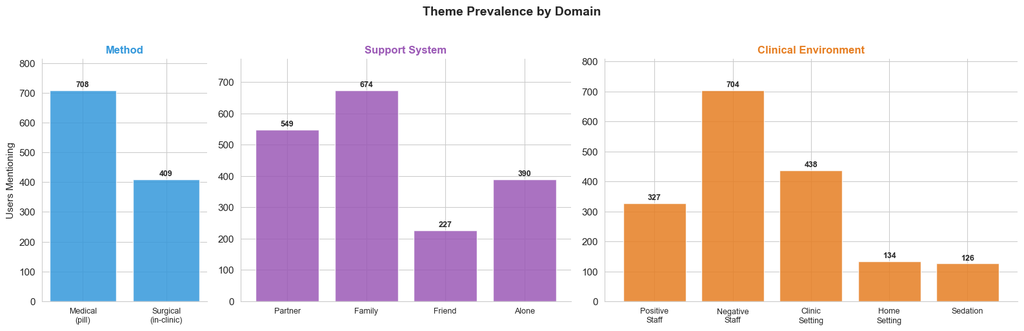

## Experience Rates by Predictor Theme

With themes extracted and experiences classified, we now compare the positive experience rate across each theme. This bivariate view shows the raw relationship before multivariate modeling. Each comparison uses Fisher's exact test with Cohen's h effect size.

Bivariate Experience Rates: Theme Present vs Absent

| Theme | n (with theme) | Pos Rate (with) | Pos Rate (without) | Odds Ratio | p-value | Cohen's h | Sig |
| --- | --- | --- | --- | --- | --- | --- | --- |
| Medical Method | 218 | 43.6% | 26.8% | 2.11 | 0.0001 | 0.354 | *** |
| Surgical Method | 122 | 45.9% | 30.3% | 1.95 | 0.0021 | 0.323 | ** |
| Partner Present | 216 | 25.9% | 40.4% | 0.52 | 0.0008 | -0.310 | *** |
| Family Support | 252 | 33.7% | 34.6% | 0.96 | 0.8507 | -0.017 |  |
| Friend Support | 76 | 35.5% | 33.9% | 1.08 | 0.7936 | 0.034 |  |
| Alone | 146 | 32.9% | 34.7% | 0.92 | 0.7558 | -0.038 |  |
| Positive Staff | 111 | 47.7% | 30.2% | 2.11 | 0.0009 | 0.361 | *** |
| Negative Staff | 250 | 36.4% | 31.9% | 1.22 | 0.2995 | 0.096 |  |
| Clinic Setting | 147 | 42.2% | 30.8% | 1.64 | 0.0171 | 0.238 | * |
| Home Setting | 45 | 35.6% | 34.0% | 1.07 | 0.8696 | 0.033 |  |
| Sedation | 41 | 51.2% | 32.6% | 2.17 | 0.0242 | 0.380 | * |

**Baseline positive experience rate:** 34.1% across 498 classified users.

**What this means:** Each row compares users who mentioned a theme to those who did not. An odds ratio above 1 means the theme is associated with more positive experiences; below 1 means more negative. Cohen's h measures the practical size of the difference (small: 0.2, medium: 0.5, large: 0.8). Starred results are statistically significant.

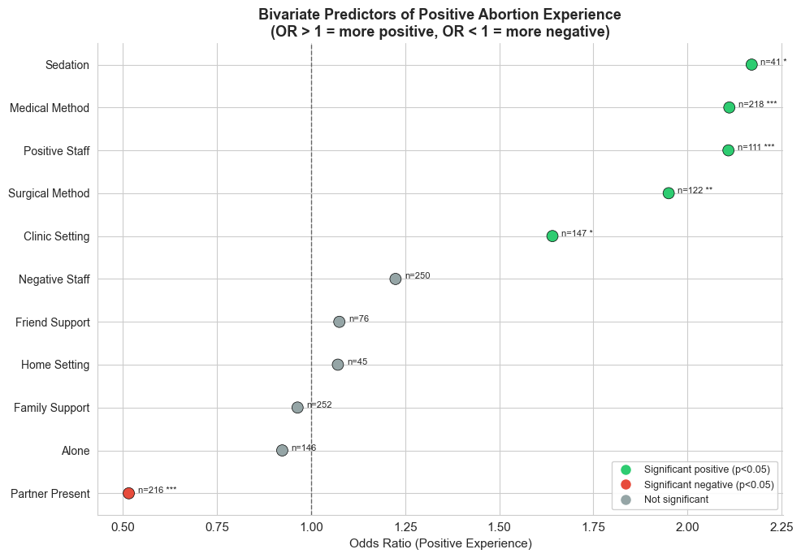

**Key takeaway:** Positive staff interactions and sedation are the strongest predictors of positive experience. Partner involvement is the strongest predictor of *negative* experience -- a counterintuitive finding explored in detail below.

## Theme Co-occurrence

Before running multivariate regression, we check how correlated the predictors are. Highly correlated predictors cause multicollinearity issues in logistic regression.

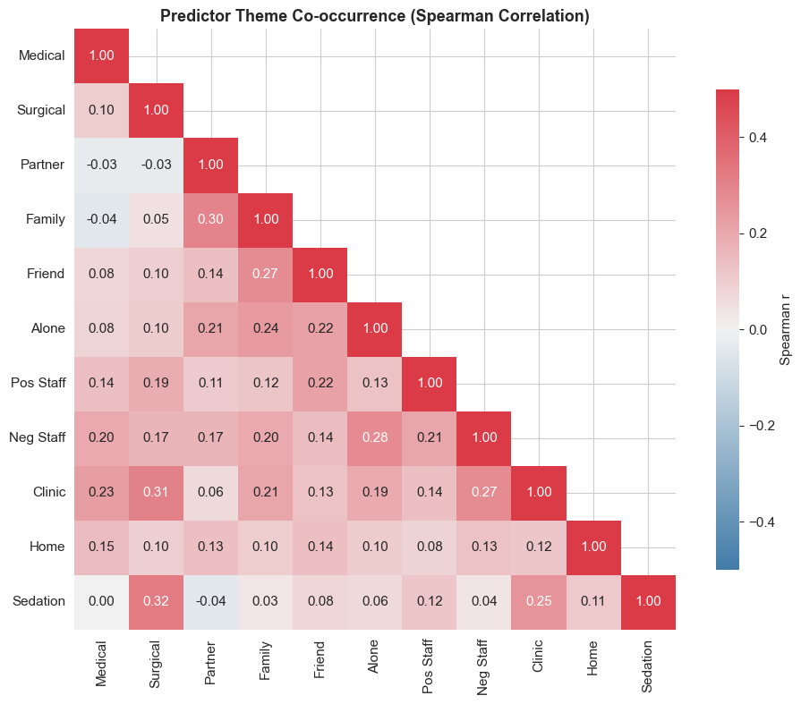

**Notable correlations (|r| > 0.3):** Surgical & Clinic: r=0.31; Surgical & Sedation: r=0.32. These will be monitored for multicollinearity in the regression.

## Logistic Regression: What Independently Predicts Experience?

The bivariate analysis showed which themes are associated with positive or negative experiences individually. But themes co-occur -- a user who mentions their partner may also mention a clinic setting. Logistic regression separates the independent contribution of each predictor, controlling for the others.

The dependent variable is binary: positive experience (1) vs negative experience (0). Predictors are all 11 theme indicators.

Logistic Regression Results: Predictors of Positive Experience

| Predictor | Odds Ratio | 95% CI Low | 95% CI High | z-statistic | p-value | Sig |
| --- | --- | --- | --- | --- | --- | --- |
| Partner Present | 0.48 | 0.31 | 0.74 | -3.35 | 0.0008 | *** |
| Alone | 0.85 | 0.53 | 1.35 | -0.69 | 0.4902 |  |
| Friend Support | 0.87 | 0.48 | 1.56 | -0.47 | 0.6364 |  |
| Home Setting | 0.89 | 0.44 | 1.79 | -0.32 | 0.7474 |  |
| Negative Staff | 1.02 | 0.66 | 1.57 | 0.10 | 0.9183 |  |
| Family Support | 1.16 | 0.75 | 1.79 | 0.65 | 0.5161 |  |
| Clinic Setting | 1.17 | 0.73 | 1.89 | 0.66 | 0.5100 |  |
| Surgical Method | 1.45 | 0.90 | 2.34 | 1.51 | 0.1309 |  |
| Sedation | 1.55 | 0.76 | 3.19 | 1.20 | 0.2309 |  |
| Medical Method | 1.93 | 1.28 | 2.91 | 3.12 | 0.0018 | ** |
| Positive Staff | 1.98 | 1.23 | 3.19 | 2.81 | 0.0049 | ** |

**Model fit:** Pseudo R-squared = 0.072, AUC = 0.680, N = 498

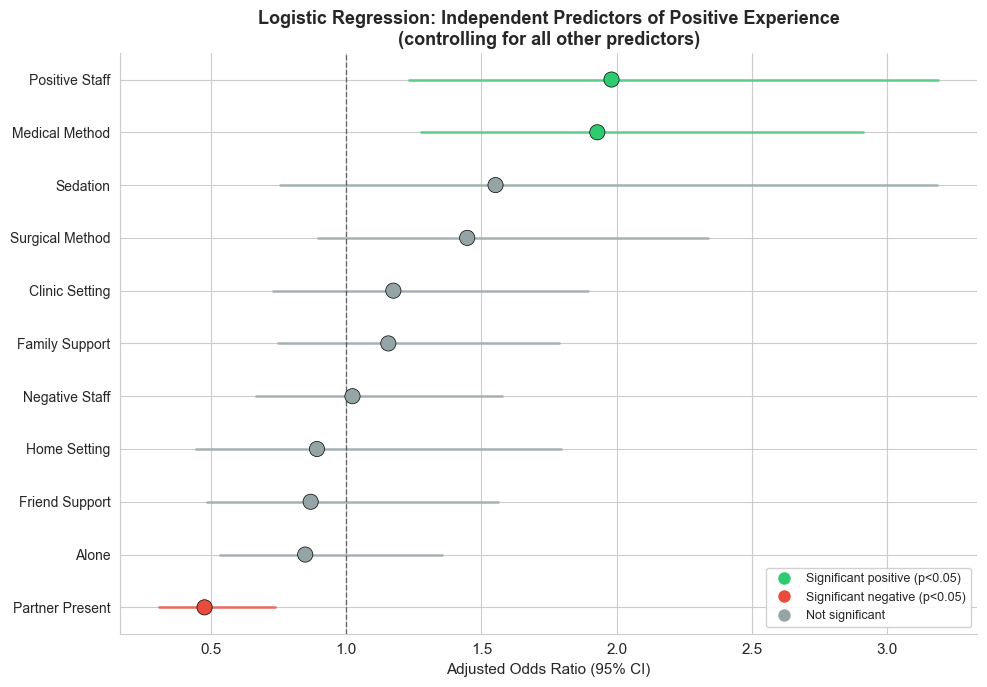

## Sensitivity Check

Does the main finding (partner involvement predicts worse experience) survive if we restrict to users with strong signal -- those who wrote at least 200 characters of text?

Sensitivity Check: Strong-Signal Users Only (text >= 200 chars)

**Sample:** 480 users (reduced from 498)

**Partner involvement effect:** OR = 0.48, p = 0.0003

**Partner positive rate:** 25.6% (n=215) vs 41.5% without partner (n=265)

**Verdict:** The partner finding is **robust** -- it survives restriction to strong-signal users.

**After dropping 3 most prolific posters:** OR = 0.49, p = 0.0004. Robust.

## Counterintuitive Findings Worth Investigating

The regression produced one finding that would surprise most clinicians and patients: **partner involvement predicts worse reported experiences.** This section examines that finding in detail.

The Partner Paradox

This contradicts the common-sense expectation that social support improves medical experiences. Several non-causal explanations are plausible:

- **Relationship stress as context:** Users mentioning partners may be navigating relationship conflict around the decision (disclosure, disagreement, pressure), which colors the entire experience negatively.

- **Selection effect:** Users who post about their partner may be posting *because* the partner dynamic is a source of distress -- people with supportive, uncomplicated partner situations may not mention them at all.

- **Gestational age confound:** Partner involvement may correlate with later gestational ages (more time for partner discovery and discussion), which are associated with more complex procedures. **We cannot test this because gestational age is not in the dataset.**

- **Verbosity bias:** Users who write about partners may write longer, more detailed posts that also capture more negative experiences simply because they describe more.

We report the correlation honestly. We do not know why it exists.

Theme Co-occurrence: Partner vs No Partner

|  | With Partner | Without Partner | Difference |
| --- | --- | --- | --- |
| Family Support | 67.6% | 37.6% | +30.0% |
| Alone | 40.3% | 20.9% | +19.4% |
| Negative Staff | 59.7% | 42.9% | +16.8% |
| exp_negative | 74.1% | 59.6% | +14.5% |
| Friend Support | 20.8% | 11.0% | +9.8% |
| Positive Staff | 27.3% | 18.4% | +8.9% |
| Home Setting | 13.4% | 5.7% | +7.8% |
| Clinic Setting | 32.9% | 27.0% | +5.9% |
| Sedation | 6.9% | 9.2% | -2.3% |
| Surgical Method | 23.1% | 25.5% | -2.4% |
| Medical Method | 42.1% | 45.0% | -2.9% |

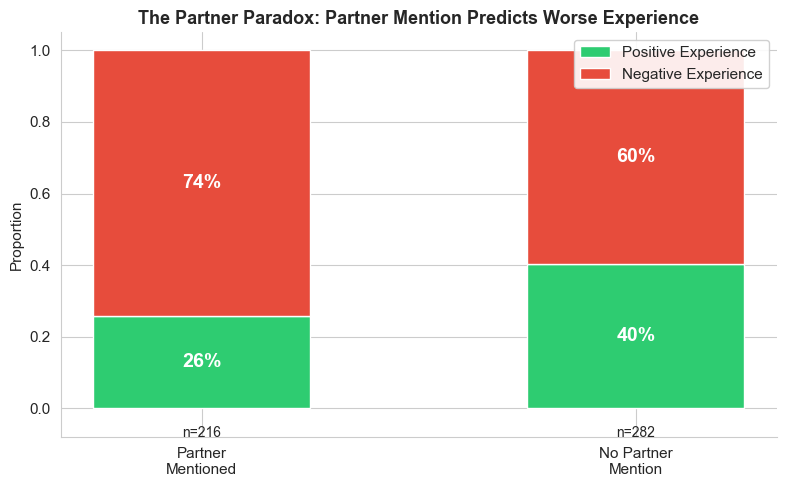

The partner finding becomes sharper when contrasted with friend support. If social support generally helps, we should see both partner and friend mentions predicting better experiences. Instead, they diverge.

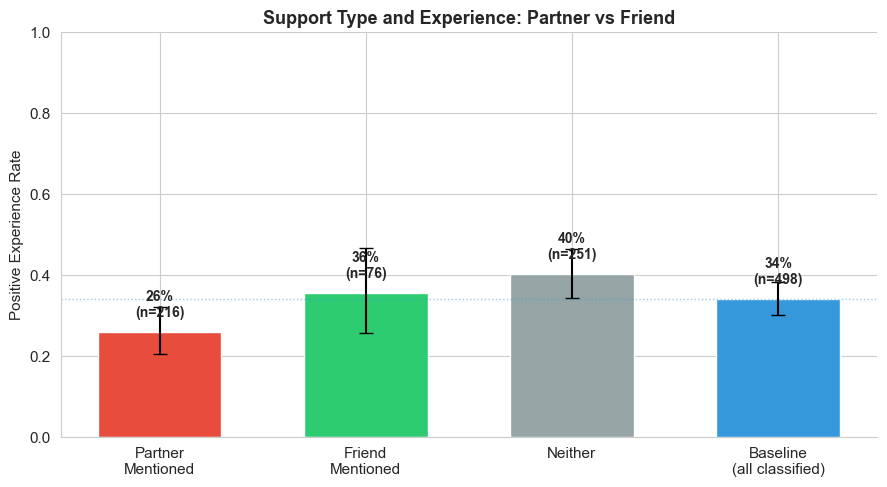

**Partner vs Friend direct comparison:** OR = 0.64, p = 0.1388, Cohen's h = -0.209.

This difference is not statistically significant at the 0.05 level.

## What Patients Are Saying *(experimental)*

Qualitative evidence drawn from post text. Each quote is from a unique user and contains a specific experiential detail, not meta-commentary. Quotes are lightly edited for clarity with [bracketed additions] where pronouns would be ambiguous. Dates indicate when the post was made.

Illustrative Quotes

Partner involvement and difficult experiences

> *"**2021- Surgical Abortion** When I was 20, about to be 21 I got pregnant by my boyfriend (29) while I was on birth control."* — (2026-03-29)

> *"i ate some more food but the cramps really started to get worse to the point where i was shivering and my legs were shaking from the pain, i had my partner with me and he was really supportive and..."* — (2026-03-24)

Friend support and positive experiences

> *"I have told a few of my friends back in California and some of my friends in New York (where I grew up), but they are all so far."* — (2026-04-07)

Clinical environment: staff quality

> *"After that, I had a few weeks back and forth with my provider, and insurance, struggling to get the Progestin-only pills as it was not covered because I had never "tried this brand before." Basically I paid a $20 fee..."* — (2026-03-17)

Complicating the narrative: supportive partner experiences

> *"With my previous partner, we created embryos together, but the relationship became unstable."* — (2026-03-18)

## Tiered Recommendations

Recommendations are based on the logistic regression results and bivariate tests. Tiers reflect evidence strength: sample size and statistical significance.

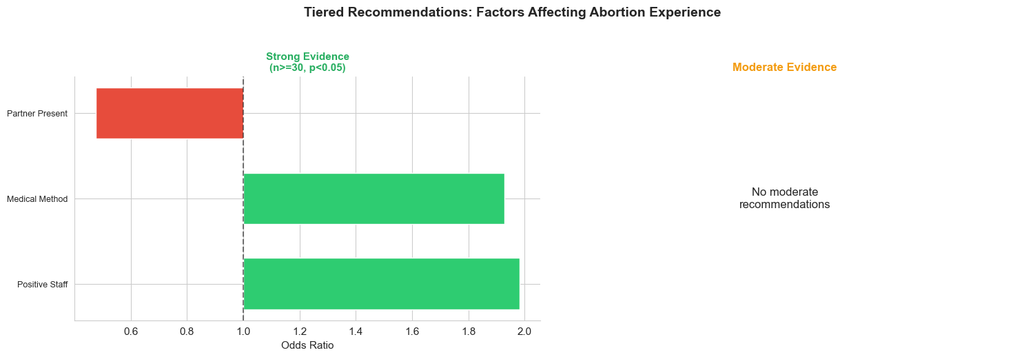

Recommendation Summary

Strong Evidence

**Positive Staff** improves reported experience (OR=1.98, p=0.0049, n=111)

**Medical Method** improves reported experience (OR=1.93, p=0.0018, n=218)

**Partner Present** worsens reported experience (OR=0.48, p=0.0008, n=216)

Preliminary Evidence

**Sedation** improves reported experience (OR=1.55, p=0.2309, n=41)

**Surgical Method** improves reported experience (OR=1.45, p=0.1309, n=122)

**Clinic Setting** improves reported experience (OR=1.17, p=0.5100, n=147)

**Family Support** improves reported experience (OR=1.16, p=0.5161, n=252)

**Negative Staff** improves reported experience (OR=1.02, p=0.9183, n=250)

**Home Setting** worsens reported experience (OR=0.89, p=0.7474, n=45)

**Friend Support** worsens reported experience (OR=0.87, p=0.6364, n=76)

**Alone** worsens reported experience (OR=0.85, p=0.4902, n=146)

## Conclusion

The question was: what predicts a positive vs negative abortion experience -- the method, the support system, or the clinical environment?

For researchers: the partner finding raises questions about the role of relationship dynamics in reproductive healthcare experiences that deserve investigation with controlled studies that include gestational age, relationship quality measures, and partner attitude toward the pregnancy.

## Research Limitations

All findings must be interpreted within these eight constraints:

**1. Selection bias.** r/abortion users are not representative of all people who have abortions. They skew younger, more internet-savvy, and disproportionately from countries with English-language Reddit access (primarily US). People who post online may also have stronger emotional reactions to share.

**2. Reporting bias.** Users who had extreme experiences -- very positive or very traumatic -- are more likely to post than those with unremarkable experiences. The middle of the experience distribution is underrepresented.

**3. Survivorship bias.** We only observe users who found Reddit and chose to post. People who had abortions and never discussed them online are invisible to this analysis.

**4. Recall bias.** Posts are written after the experience, sometimes weeks or months later. Memory reshapes experiences -- a positive outcome may retroactively color a difficult procedure as "not that bad," and ongoing regret may darken an initially neutral experience.

**5. Confounding variables -- CRITICAL.** **Gestational age is not controlled for in this analysis.** This is a major limitation. Gestational age affects method availability, procedural complexity, physical pain, emotional weight, and social circumstances. The partner finding, the method finding, and the clinical environment findings could all be confounded by gestational age. For example, partner involvement may correlate with later gestational ages (more time for partner to learn about the pregnancy), and later gestational ages involve more complex procedures with worse physical experiences. Without gestational age data, we cannot disentangle these effects. Other uncontrolled confounders include: prior reproductive history, mental health history, financial stress, and legal/access barriers.

**6. No control group.** There is no comparison to people who considered but did not have an abortion, or to other medical procedures. We cannot say whether the experience rates observed here are better or worse than other healthcare contexts.

**7. Text mining is not sentiment analysis.** Our keyword-based theme extraction catches explicit mentions but misses nuance. A user who writes "I thought I would feel guilty but I don't" gets tagged for guilt when the actual sentiment is its opposite. Negation handling is imperfect. The outcome classifier is conservative to mitigate this, but misclassification is inevitable.

**8. Temporal snapshot.** This data covers one month (March-April 2026). Experiences may shift seasonally, with policy changes, or as community norms evolve. These findings should not be treated as stable population parameters.

These findings reflect reporting patterns in online communities, not population-level treatment effects. This is not medical advice.